# NHOM_2_FINAL_PROJECT_02

##### Evaluation

```r
pred_out_md_LDA <- predict(lda_diabetes_md3, newdata = testing)
posterior_probs <- pred_out_md_LDA$posterior
## Gán nhãn tập testing
testing$predicted_LDA <- colnames(posterior_probs)[max.col(posterior_probs)]
```

```r
conf_matrix <- table(Actual = testing$diabetes_012, Predicted = testing$predicted_LDA)
```

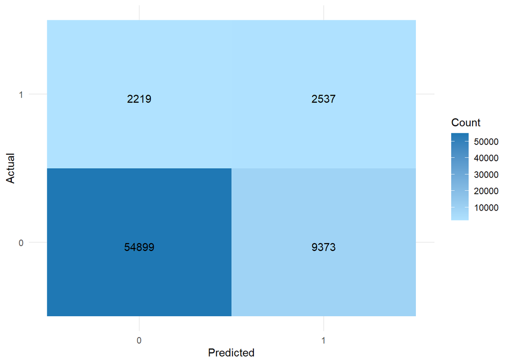

```r
# Trực quan hóa confusion matrix
cm_table <- as.table(conf_matrix)
cm_melt <- as.data.frame(as.table(cm_table))

ggplot(data = cm_melt, aes(x = Actual, y = Predicted, fill = Freq)) +
  geom_tile() +
  geom_text(aes(label = sprintf("%d", Freq)), vjust = 1) +
  scale_fill_gradient(low = "lightskyblue1", high = "#1f78b4") +
  theme_minimal() +
  labs(x = "Predicted", y = "Actual", fill = "Count")
```

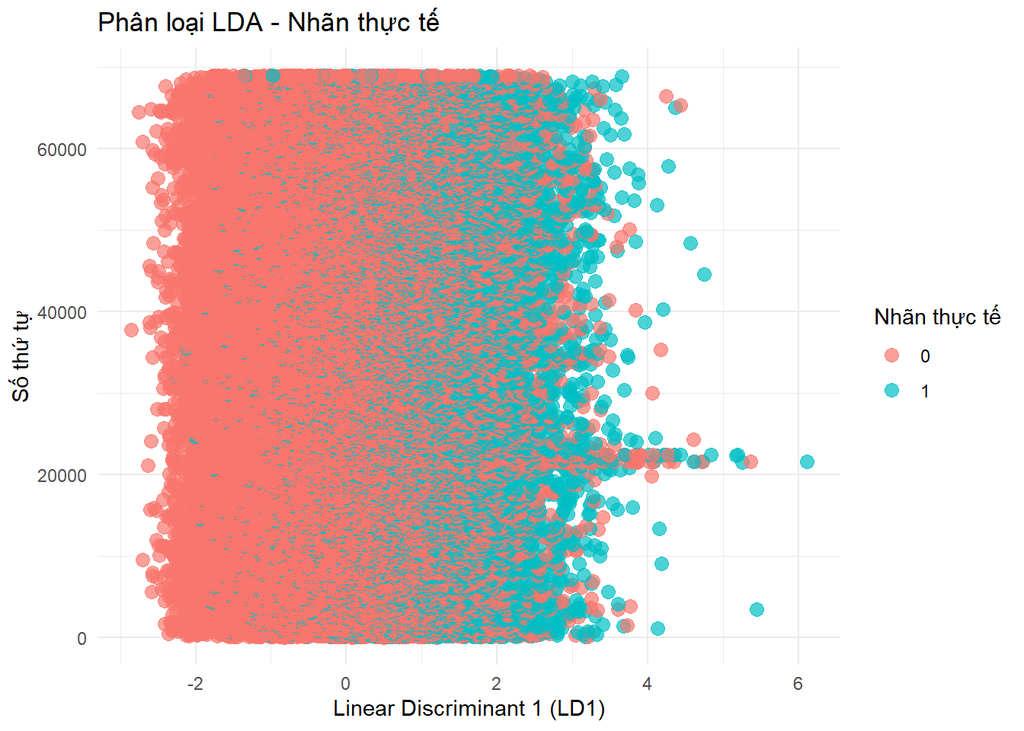

```r
# Bước 1: Tính toán giá trị discriminant
lda_pred <- predict(lda_diabetes_md3, testing)

# Bước 2: Trích xuất các giá trị discriminant (Linear Discriminants)
lda_values <- lda_pred$x  # Ma trận các giá trị discriminant

plot_data <- data.frame(
  LD1 = lda_values[, 1],  # Trục Linear Discriminant 1
  Actual = factor(testing$diabetes_012),   # Nhãn thực tế
  Predicted = factor(lda_pred$class)      # Nhãn dự đoán
)

# Thêm cột "Index" để làm trục y (số thứ tự các điểm)
plot_data <- plot_data %>%
  mutate(Index = 1:nrow(plot_data))  # Số thứ tự các điểm

# Vẽ phân loại dựa trên LD1 và nhãn thực tế
ggplot(plot_data, aes(x = LD1, y = Index, color = Actual)) +
  geom_point(alpha = 0.7, size = 3) +
  labs(
    title = "Phân loại LDA - Nhãn thực tế",
    x = "Linear Discriminant 1 (LD1)",
    y = "Số thứ tự",
    color = "Nhãn thực tế"
  ) +
  theme_minimal()
```

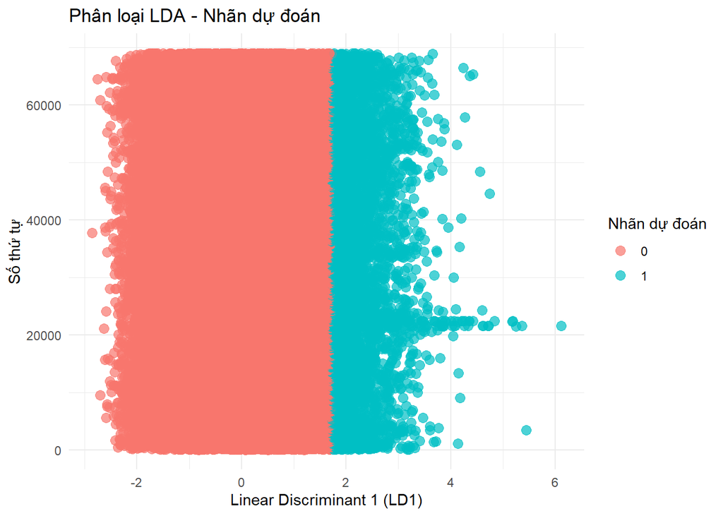

```r
# Vẽ phân loại dựa trên LD1 và nhãn dự đoán
ggplot(plot_data, aes(x = LD1, y = Index, color = Predicted)) +
  geom_point(alpha = 0.7, size = 3) +
  labs(
    title = "Phân loại LDA - Nhãn dự đoán",
    x = "Linear Discriminant 1 (LD1)",
    y = "Số thứ tự",
    color = "Nhãn dự đoán"
  ) +
  theme_minimal()
```

### 4.4.5 LDA: Imbalanced Data

#### Imbalanced data cho 3 nhóm

Ta xem số quan sát ở mỗi nhóm trong biến `diabetes_012`

```r
table(diabetes1$diabetes_012)
```

```
##
##      0      1      2
## 190055   4629  35097
```

```r
library(themis)

set.seed(123)
smotenc_diabetes1 <- smotenc(df = diabetes1, var = "diabetes_012",
                          k = 5, over_ratio = 1)
glimpse(smotenc_diabetes1)
```

```
## Rows: 570,165
## Columns: 22
## $ diabetes_012           <fct> 0, 0, 0, 0, 0, 0, 0, 0, 2, 0, 2, 0, 0, 2, 0, 0,…
## $ high_bp                <fct> 1, 0, 1, 1, 1, 1, 1, 1, 1, 0, 0, 1, 0, 1, 0, 1,…
## $ high_chol              <fct> 1, 0, 1, 0, 1, 1, 0, 1, 1, 0, 0, 1, 0, 1, 1, 0,…
## $ chol_check             <fct> 1, 0, 1, 1, 1, 1, 1, 1, 1, 1, 1, 1, 1, 1, 1, 1,…
## $ bmi                    <dbl> 40, 25, 28, 27, 24, 25, 30, 25, 30, 24, 25, 34,…
## $ smoker                 <fct> 1, 1, 0, 0, 0, 1, 1, 1, 1, 0, 1, 1, 1, 0, 1, 0,…
## $ stroke                 <fct> 0, 0, 0, 0, 0, 0, 0, 0, 0, 0, 0, 0, 0, 0, 1, 0,…
## $ heart_diseaseor_attack <fct> 0, 0, 0, 0, 0, 0, 0, 0, 1, 0, 0, 0, 0, 0, 0, 0,…
## $ phys_activity          <fct> 0, 1, 0, 1, 1, 1, 0, 1, 0, 0, 1, 0, 0, 0, 1, 1,…
## $ fruits                 <fct> 0, 0, 1, 1, 1, 1, 0, 0, 1, 0, 1, 1, 0, 0, 0, 0,…
## $ veggies                <fct> 1, 0, 0, 1, 1, 1, 0, 1, 1, 1, 1, 1, 1, 1, 1, 0,…
## $ hvy_alcohol_consump    <fct> 0, 0, 0, 0, 0, 0, 0, 0, 0, 0, 0, 0, 0, 0, 0, 0,…
## $ any_healthcare         <fct> 1, 0, 1, 1, 1, 1, 1, 1, 1, 1, 1, 1, 1, 1, 1, 1,…
## $ no_docbc_cost          <fct> 0, 1, 1, 0, 0, 0, 0, 0, 0, 0, 0, 0, 0, 0, 1, 0,…
## $ gen_hlth               <dbl> 5, 3, 5, 2, 2, 2, 3, 3, 5, 2, 3, 3, 3, 4, 4, 2,…
## $ ment_hlth              <dbl> 18, 0, 30, 0, 3, 0, 0, 0, 30, 0, 0, 0, 0, 0, 30…
## $ phys_hlth              <dbl> 15, 0, 30, 0, 0, 2, 14, 0, 30, 0, 0, 30, 15, 0,…
## $ diff_walk              <fct> 1, 0, 1, 0, 0, 0, 0, 1, 1, 0, 0, 1, 0, 1, 0, 0,…
## $ sex                    <fct> 0, 0, 0, 0, 0, 1, 0, 0, 0, 1, 1, 0, 0, 0, 0, 0,…
## $ age                    <fct> 9, 7, 9, 11, 11, 10, 9, 11, 9, 8, 13, 10, 7, 11…
## $ education              <fct> 4, 6, 4, 3, 5, 6, 6, 4, 5, 4, 6, 5, 5, 4, 6, 6,…
## $ income                 <fct> 3, 1, 8, 6, 4, 8, 7, 4, 1, 3, 8, 1, 7, 6, 2, 8,…
```

```r
with(smotenc_diabetes1, table(diabetes_012))
```

```
## diabetes_012
##      0      1      2
## 190055 190055 190055
```

```r
summary(smotenc_diabetes1)
```

```
##  diabetes_012 high_bp    high_chol  chol_check      bmi        smoker
##  0:190055     0:227051   0:245186   0:  9441   Min.   :12.00   0:290877
##  1:190055     1:343114   1:324979   1:560724   1st Qu.:26.00   1:279288
##  2:190055                                      Median :29.12
##                                                Mean   :30.13
##                                                3rd Qu.:33.14
##                                                Max.   :98.00
##
##  stroke     heart_diseaseor_attack phys_activity fruits     veggies
##  0:547083   0:494704               0:173625      0:224194   0:118566
##  1: 23082   1: 75461               1:396540      1:345971   1:451599
##
##
##
##
##
##  hvy_alcohol_consump any_healthcare no_docbc_cost    gen_hlth
##  0:553306            0: 19534       0:521344      Min.   :1.000
##  1: 16859            1:550631       1: 48821      1st Qu.:2.000
##                                                   Median :3.000
##                                                   Mean   :2.895
##                                                   3rd Qu.:3.689
##                                                   Max.   :5.000
##
##    ment_hlth        phys_hlth       diff_walk  sex             age
##  Min.   : 0.000   Min.   : 0.0000   0:423873   0:315013   10     : 93950
##  1st Qu.: 0.000   1st Qu.: 0.0000   1:146292   1:255152   9      : 89037
##  Median : 0.000   Median : 0.3756                         11     : 72270
##  Mean   : 3.729   Mean   : 5.7597                         8      : 69577
##  3rd Qu.: 2.943   3rd Qu.: 6.0982                         7      : 51114
##  Max.   :30.000   Max.   :30.0000                         13     : 49033
##                                                           (Other):145184
##  education      income
##  1:   197   8      :152919
##  2:  9800   7      : 95893
##  3: 24871   6      : 90926
##  4:170519   5      : 67017
##  5:168958   4      : 53608
##  6:195820   3      : 45946
##             (Other): 63856
```

#### Imbalanced data cho 2 nhóm

Ta xem số quan sát ở mỗi nhóm trong biến `diabetes_012`

```r
table(diabetes2$diabetes_012)
```

```
##
##      0      1
## 190055  39726
```

**Nhận xét:** ta thấy có sự chênh lệch đáng kể. Do đó ta sẽ sử dụng phương pháp SMOTE để tạo lặp mẫu sao cho hai nhóm cân bằng nhau.

```r
library(themis)

set.seed(123)
smotenc_diabetes2 <- smotenc(df = diabetes2, var = "diabetes_012",
                          k = 5, over_ratio = 1)
glimpse(smotenc_diabetes2)
```

```
## Rows: 380,110
## Columns: 22
## $ diabetes_012           <fct> 0, 0, 0, 0, 0, 0, 0, 0, 1, 0, 1, 0, 0, 1, 0, 0,…
## $ high_bp                <fct> 1, 0, 1, 1, 1, 1, 1, 1, 1, 0, 0, 1, 0, 1, 0, 1,…
## $ high_chol              <fct> 1, 0, 1, 0, 1, 1, 0, 1, 1, 0, 0, 1, 0, 1, 1, 0,…
## $ chol_check             <fct> 1, 0, 1, 1, 1, 1, 1, 1, 1, 1, 1, 1, 1, 1, 1, 1,…
## $ bmi                    <dbl> 40, 25, 28, 27, 24, 25, 30, 25, 30, 24, 25, 34,…
## $ smoker                 <fct> 1, 1, 0, 0, 0, 1, 1, 1, 1, 0, 1, 1, 1, 0, 1, 0,…
## $ stroke                 <fct> 0, 0, 0, 0, 0, 0, 0, 0, 0, 0, 0, 0, 0, 0, 1, 0,…
## $ heart_diseaseor_attack <fct> 0, 0, 0, 0, 0, 0, 0, 0, 1, 0, 0, 0, 0, 0, 0, 0,…
## $ phys_activity          <fct> 0, 1, 0, 1, 1, 1, 0, 1, 0, 0, 1, 0, 0, 0, 1, 1,…
## $ fruits                 <fct> 0, 0, 1, 1, 1, 1, 0, 0, 1, 0, 1, 1, 0, 0, 0, 0,…
## $ veggies                <fct> 1, 0, 0, 1, 1, 1, 0, 1, 1, 1, 1, 1, 1, 1, 1, 0,…
## $ hvy_alcohol_consump    <fct> 0, 0, 0, 0, 0, 0, 0, 0, 0, 0, 0, 0, 0, 0, 0, 0,…
## $ any_healthcare         <fct> 1, 0, 1, 1, 1, 1, 1, 1, 1, 1, 1, 1, 1, 1, 1, 1,…
## $ no_docbc_cost          <fct> 0, 1, 1, 0, 0, 0, 0, 0, 0, 0, 0, 0, 0, 0, 1, 0,…
## $ gen_hlth               <dbl> 5, 3, 5, 2, 2, 2, 3, 3, 5, 2, 3, 3, 3, 4, 4, 2,…
## $ ment_hlth              <dbl> 18, 0, 30, 0, 3, 0, 0, 0, 30, 0, 0, 0, 0, 0, 30…
## $ phys_hlth              <dbl> 15, 0, 30, 0, 0, 2, 14, 0, 30, 0, 0, 30, 15, 0,…
## $ diff_walk              <fct> 1, 0, 1, 0, 0, 0, 0, 1, 1, 0, 0, 1, 0, 1, 0, 0,…
## $ sex                    <fct> 0, 0, 0, 0, 0, 1, 0, 0, 0, 1, 1, 0, 0, 0, 0, 0,…
## $ age                    <fct> 9, 7, 9, 11, 11, 10, 9, 11, 9, 8, 13, 10, 7, 11…
## $ education              <fct> 4, 6, 4, 3, 5, 6, 6, 4, 5, 4, 6, 5, 5, 4, 6, 6,…
## $ income                 <fct> 3, 1, 8, 6, 4, 8, 7, 4, 1, 3, 8, 1, 7, 6, 2, 8,…
```

```r
with(smotenc_diabetes2, table(diabetes_012))
```

```
## diabetes_012
##      0      1
## 190055 190055
```

**Nhận xét:** dữ liệu hai nhóm đã cân bằng.

```r
summary(smotenc_diabetes2)
```

```
##  diabetes_012 high_bp    high_chol  chol_check      bmi        smoker
##  0:190055     0:161839   0:176801   0:  9433   Min.   :12.00   0:195446
##  1:190055     1:218271   1:203309   1:370677   1st Qu.:25.52   1:184664
##                                                Median :29.00
##                                                Mean   :29.86
##                                                3rd Qu.:33.00
##                                                Max.   :98.00
##
##  stroke     heart_diseaseor_attack phys_activity fruits     veggies
##  0:360722   0:327022               0:114861      0:150261   0: 80790
##  1: 19388   1: 53088               1:265249      1:229849   1:299320
##
##
##
##
##
##  hvy_alcohol_consump any_healthcare no_docbc_cost    gen_hlth
##  0:364937            0: 15586       0:346819      Min.   :1.000
##  1: 15173            1:364524       1: 33291      1st Qu.:2.000
##                                                   Median :3.000
##                                                   Mean   :2.855
##                                                   3rd Qu.:3.726
##                                                   Max.   :5.000
##
##    ment_hlth        phys_hlth      diff_walk  sex             age
##  Min.   : 0.000   Min.   : 0.000   0:284639   0:208333   10     : 59367
##  1st Qu.: 0.000   1st Qu.: 0.000   1: 95471   1:171777   9      : 55895
##  Median : 0.000   Median : 0.000                         8      : 45830
##  Mean   : 3.661   Mean   : 5.708                         11     : 45312
##  3rd Qu.: 2.636   3rd Qu.: 5.733                         7      : 35379
##  Max.   :30.000   Max.   :30.000                         13     : 30628
##                                                          (Other):107699
##  education      income
##  1:   201   8      :105163
##  2:  7118   7      : 63583
##  3: 16827   6      : 58661
##  4:110427   5      : 44397
##  5:111820   4      : 36524
##  6:133717   3      : 29907
##             (Other): 41875
```

#### LDA trên balance data 3 nhóm

#### Validation

```r
set.seed(123)
ind <- sample(2, nrow(smotenc_diabetes1),
              replace = TRUE,
              prob = c(0.7, 0.3))
training <- smotenc_diabetes1[ind==1,]
testing <- smotenc_diabetes1[ind==2,]
```

#### Model

```r
lda_diabetes_md4 <- lda(formula = formula_model, data = training)
lda_diabetes_md4
```

```
## Call:
## lda(formula_model, data = training)
##
## Prior probabilities of groups:
##         0         1         2
## 0.3329701 0.3330503 0.3339796
##
## Group means:
##    high_bp1 high_chol1 chol_check1      bmi   smoker1    stroke1
## 0 0.3946456  0.3948938   0.9523684 28.03123 0.4548094 0.03588918
## 1 0.6434733  0.6360054   0.9994284 30.51135 0.4930999 0.01611654
## 2 0.7685541  0.6784836   0.9981251 31.84597 0.5200015 0.06926654
##   heart_diseaseor_attack1 phys_activity1 hvy_alcohol_consump1 gen_hlth
## 0              0.07957153      0.7548237           0.06783664 2.461820
## 1              0.10788229      0.6962751           0.01024299 2.935414
## 2              0.20826459      0.6361182           0.01050697 3.284150
##   ment_hlth phys_hlth diff_walk1        age2        age3       age4       age5
## 0  3.296516  4.017038  0.1482206 0.036257776 0.050760887 0.06073554 0.06751318
## 1  3.854788  5.652066  0.2543375 0.004459686 0.005948755 0.02062887 0.01778610
## 2  4.022816  7.617212  0.3666867 0.001604920 0.004559772 0.01122694 0.02162892
##         age6       age7      age8      age9     age10      age11      age12
## 0 0.07986490 0.10348511 0.1182665 0.1229078 0.1157992 0.08607085 0.06069040
## 1 0.05491506 0.08401206 0.1256533 0.1750859 0.1781693 0.13806226 0.09755657
## 2 0.04065547 0.08167842 0.1225139 0.1716814 0.1998875 0.15650967 0.09520774
##        age13    income2    income3    income4   income5   income6   income7
## 0 0.06910040 0.04338145 0.06290198 0.08119636 0.1071109 0.1527039 0.1804539
## 1 0.09609007 0.05680271 0.08278621 0.08853943 0.1166212 0.1715663 0.1702352
## 2 0.09185541 0.08051597 0.09586021 0.11150442 0.1296610 0.1547023 0.1552797
##     income8
## 0 0.3351362
## 1 0.2547586
## 2 0.2136643
##
## Coefficients of linear discriminants:
##                                  LD1          LD2
## high_bp1                 0.514486383  0.390050663
## high_chol1               0.442120637 -0.410574574
## chol_check1              1.583041130 -1.795072199
## bmi                      0.054584993  0.011256355
## smoker1                 -0.011354600 -0.067975829
```

[output cut: 16 more lines]

```
## age10                    2.033345808 -1.879668022
## age11                    2.103350986 -1.924023224
## age12                    2.025180122 -2.388769772
## age13                    1.917028863 -2.564599628
## income2                 -0.054231338  0.892028695
## income3                 -0.039867046  0.613585283
## income4                 -0.064362942  0.947862728
## income5                 -0.048633201  0.799212089
## income6                 -0.062586612  0.478413620
## income7                 -0.068716827  0.649413145
## income8                 -0.113550614  0.700494113
##
## Proportion of trace:
##    LD1    LD2
## 0.9123 0.0877
```

**Nhận xét:** từ mô hình LDA, ta thấy trong tập training:

• Có khoảng 33.3% quan sát được phân loại vào nhóm 0, tức là không có mắc bệnh tiểu đường;

• Có khoảng 33.3% quan sát được phân loại vào nhóm 1, tức tiền tiểu đường;

• Có khoảng 33.4% quan sát được phân loại vào nhóm 2, tức là có mắc bệnh tiểu đường;

```r
lda_diabetes_md4$count
```

```
##      0      1      2
## 132937 132969 133340
```

```r
lda_diabetes_md4$scaling
```

```
##                                  LD1          LD2
## high_bp1                 0.514486383  0.390050663
## high_chol1               0.442120637 -0.410574574
## chol_check1              1.583041130 -1.795072199
## bmi                      0.054584993  0.011256355
## smoker1                 -0.011354600 -0.067975829
## stroke1                 -0.321617619  2.326302058
## heart_diseaseor_attack1  0.060008063  1.228102958
## phys_activity1           0.031525723 -0.146583741
## hvy_alcohol_consump1    -1.381198812  1.286543101
## gen_hlth                 0.500590063  0.232364103
## ment_hlth               -0.005753734 -0.031648331
## phys_hlth               -0.010854577  0.006232655
## diff_walk1              -0.020747014  0.410101778
## age2                     0.103254700 -0.523837908
## age3                     0.146973775 -0.341446369
## age4                     0.691033597 -1.373066107
## age5                     0.752548983 -0.560452898
## age6                     1.245462942 -1.849401319
## age7                     1.482337103 -1.609740045
## age8                     1.629347428 -1.886901765
## age9                     1.889363526 -2.085996132
## age10                    2.033345808 -1.879668022
## age11                    2.103350986 -1.924023224
## age12                    2.025180122 -2.388769772
## age13                    1.917028863 -2.564599628
## income2                 -0.054231338  0.892028695
## income3                 -0.039867046  0.613585283
## income4                 -0.064362942  0.947862728
## income5                 -0.048633201  0.799212089
## income6                 -0.062586612  0.478413620
## income7                 -0.068716827  0.649413145
## income8                 -0.113550614  0.700494113
```

#### Hist

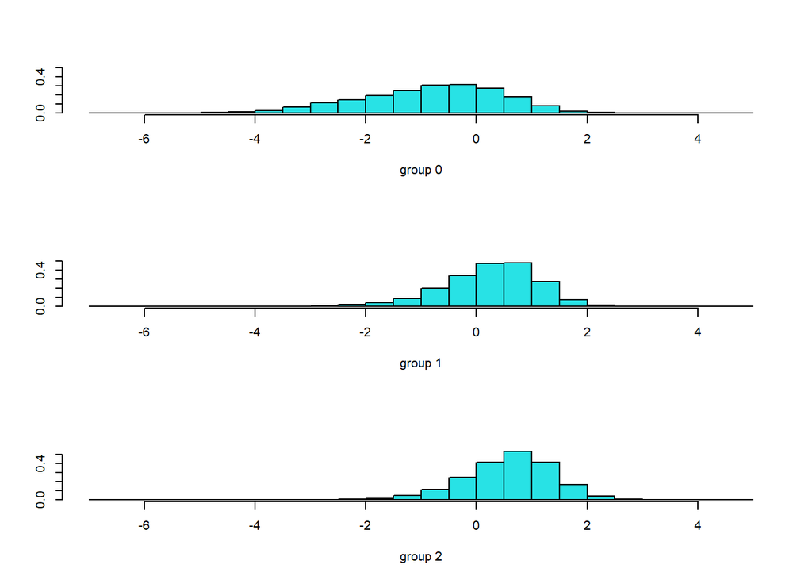

```r
p <- predict(lda_diabetes_md4, training)
ldahist(data = p$x[,1], g = training$diabetes_012)
```

**Nhận xét:** ta nhận thấy rằng có sự trùng lặp giữa các đồ thị histogram giá trị LDA của 3 nhóm, do đó mô hình không có sự phân loại tốt giữa 3 nhóm.

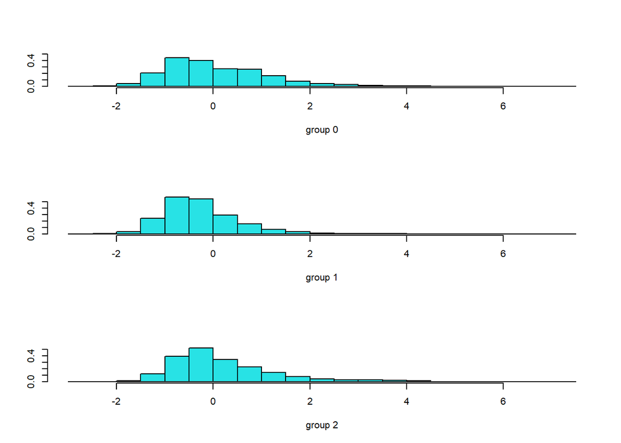

```r
ldahist(data = p$x[,2], g = training$diabetes_012)
```

#### Bi-plot

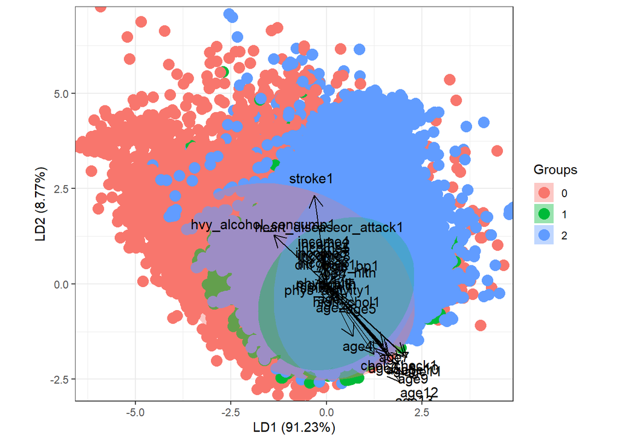

```r
ggord(lda_diabetes_md4, training$diabetes_012)
```

#### Evaluation

```r
pred_out_md_LDA <- predict(lda_diabetes_md4, newdata = testing)
posterior_probs <- pred_out_md_LDA$posterior
## Gán nhãn tập testing
testing$predicted_LDA <- colnames(posterior_probs)[max.col(posterior_probs)]
```

```r
conf_matrix <- table(Actual = testing$diabetes_012, Predicted = testing$predicted_LDA)
```

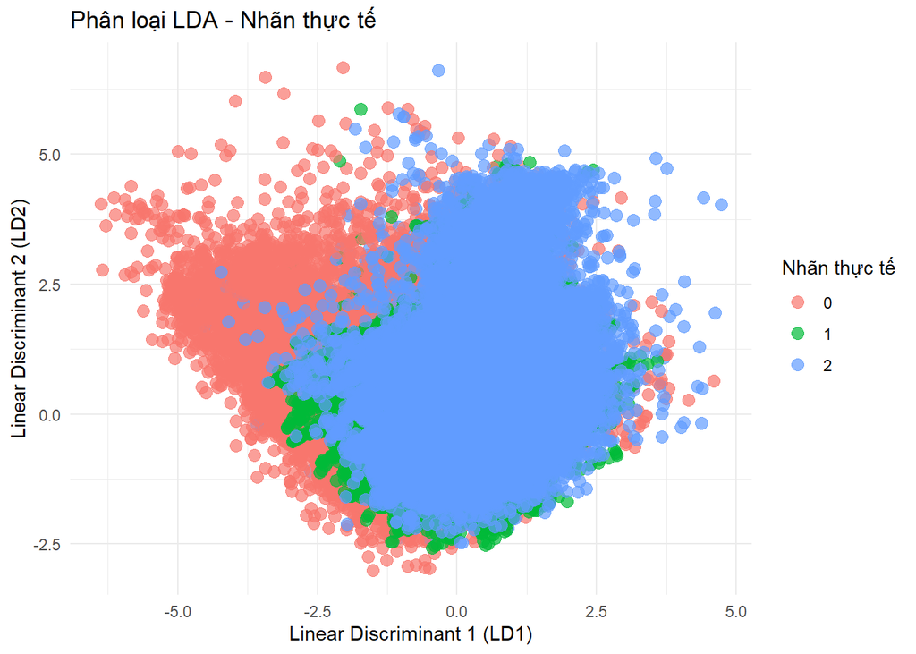

```r
# Bước 1: Tính toán giá trị discriminant
lda_pred <- predict(lda_diabetes_md4, testing)

# Bước 2: Trích xuất các giá trị discriminant (Linear Discriminants)
lda_values <- lda_pred$x  # Ma trận các giá trị discriminant

plot_data <- data.frame(
  LD1 = lda_values[, 1],  # Trục Linear Discriminant 1
  LD2 = lda_values[, 2],  # Trục Linear Discriminant 2 (nếu có)
  Actual = factor(testing$diabetes_012),   # Nhãn thực tế
  Predicted = factor(lda_pred$class)      # Nhãn dự đoán
)

library(ggplot2)

ggplot(plot_data, aes(x = LD1, y = LD2, color = Actual)) +
  geom_point(alpha = 0.7, size = 3) +
  labs(title = "Phân loại LDA - Nhãn thực tế",
       x = "Linear Discriminant 1 (LD1)",
       y = "Linear Discriminant 2 (LD2)",
       color = "Nhãn thực tế") +
  theme_minimal()
```

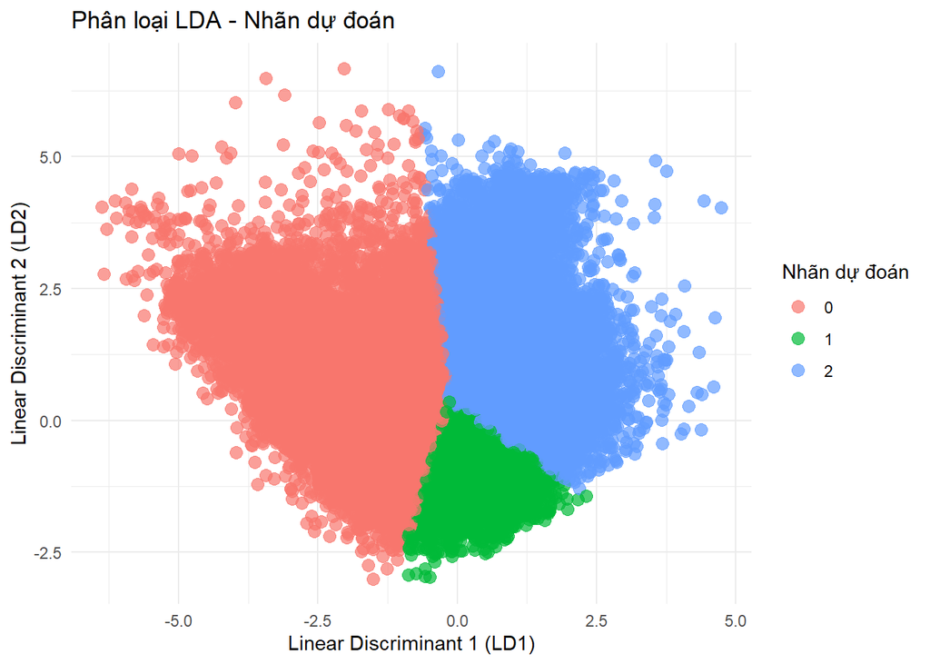

```r
ggplot(plot_data, aes(x = LD1, y = LD2, color = Predicted)) +
  geom_point(alpha = 0.7, size = 3) +
  labs(title = "Phân loại LDA - Nhãn dự đoán",
       x = "Linear Discriminant 1 (LD1)",
       y = "Linear Discriminant 2 (LD2)",
       color = "Nhãn dự đoán") +
  theme_minimal()
```

#### LDA trên balanced data 2 nhóm

#### Validation

```r
set.seed(123)
ind <- sample(2, nrow(smotenc_diabetes2),
              replace = TRUE,
              prob = c(0.7, 0.3))
training <- smotenc_diabetes2[ind==1,]
testing <- smotenc_diabetes2[ind==2,]
```

#### Model

```r
lda_diabetes_md5 <- lda(formula = formula_model, data = training)
lda_diabetes_md5
```

```
## Call:
## lda(formula_model, data = training)
##
## Prior probabilities of groups:
##         0         1
## 0.5000658 0.4999342
##
## Group means:
##    high_bp1 high_chol1 chol_check1      bmi   smoker1    stroke1
## 0 0.3946456  0.3948938   0.9523684 28.03123 0.4548094 0.03588918
## 1 0.7538788  0.6749108   0.9975621 31.70695 0.5156431 0.06632707
##   heart_diseaseor_attack1 phys_activity1 hvy_alcohol_consump1 gen_hlth
## 0              0.07957153      0.7548237           0.06783664 2.461820
## 1              0.19929723      0.6409083           0.01200885 3.246749
##   ment_hlth phys_hlth diff_walk1        age2        age3       age4       age5
## 0  3.296516  4.017038  0.1482206 0.036257776 0.050760887 0.06073554 0.06751318
## 1  4.016944  7.407394  0.3538096 0.002422838 0.005507818 0.01306226 0.02208394
##         age6       age7      age8      age9     age10      age11      age12
## 0 0.07986490 0.10348511 0.1182665 0.1229078 0.1157992 0.08607085 0.06069040
## 1 0.04334021 0.08282042 0.1229026 0.1715174 0.1964605 0.15290966 0.09465621
##        age13    income2    income3    income4   income5   income6   income7
## 0 0.06910040 0.04338145 0.06290198 0.08119636 0.1071109 0.1527039 0.1804539
## 1 0.09124769 0.07953229 0.09446058 0.11044228 0.1273645 0.1558366 0.1549563
##     income8
## 0 0.3351362
## 1 0.2174911
##
## Coefficients of linear discriminants:
##                                  LD1
## high_bp1                 0.635318535
## high_chol1               0.458767038
## chol_check1              0.870744008
## bmi                      0.052315372
## smoker1                 -0.007732403
## stroke1                 -0.217160186
## heart_diseaseor_attack1  0.128144844
## phys_activity1           0.009368572
## hvy_alcohol_consump1    -0.947173887
## gen_hlth                 0.494594886
## ment_hlth               -0.007784458
## phys_hlth               -0.010436719
## diff_walk1               0.074598128
## age2                    -0.035343249
## age3                    -0.010613242
## age4                     0.172479917
## age5                     0.301972618
## age6                     0.566858263
## age7                     0.798800481
## age8                     0.925020265
## age9                     1.151212855
## age10                    1.312661742
## age11                    1.363585280
## age12                    1.256075876
## age13                    1.142598266
## income2                 -0.010931097
## income3                 -0.033553396
## income4                 -0.029483798
## income5                 -0.064856185
## income6                 -0.079581678
## income7                 -0.099586791
## income8                 -0.109795438
```

**Nhận xét:** từ mô hình LDA, ta thấy trong tập training:

• Có khoảng 50% quan sát được phân loại vào nhóm 0, tức là không có mắc bệnh tiểu đường;

• Có khoảng 50% quan sát được phân loại vào nhóm 1, tức mắc bệnh tiểu đường;

```r
lda_diabetes_md5$count
```

```
##      0      1
## 132937 132902
```

```r
lda_diabetes_md5$scaling
```

```
##                                  LD1
## high_bp1                 0.635318535
## high_chol1               0.458767038
## chol_check1              0.870744008
## bmi                      0.052315372
## smoker1                 -0.007732403
## stroke1                 -0.217160186
## heart_diseaseor_attack1  0.128144844
## phys_activity1           0.009368572
## hvy_alcohol_consump1    -0.947173887
## gen_hlth                 0.494594886
## ment_hlth               -0.007784458
## phys_hlth               -0.010436719
## diff_walk1               0.074598128
## age2                    -0.035343249
## age3                    -0.010613242
## age4                     0.172479917
## age5                     0.301972618
## age6                     0.566858263
## age7                     0.798800481
## age8                     0.925020265
## age9                     1.151212855
## age10                    1.312661742
## age11                    1.363585280
## age12                    1.256075876
## age13                    1.142598266
## income2                 -0.010931097
## income3                 -0.033553396
## income4                 -0.029483798
## income5                 -0.064856185
## income6                 -0.079581678
## income7                 -0.099586791
## income8                 -0.109795438
```

#### Hist

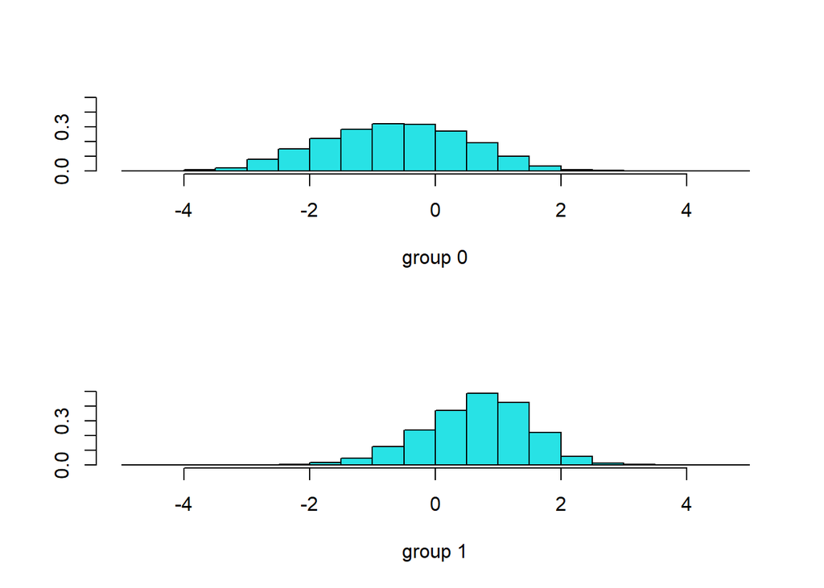

```r
p <- predict(lda_diabetes_md5, training)
ldahist(data = p$x[,1], g = training$diabetes_012)
```

#### Evaluation

```r
pred_out_md_LDA <- predict(lda_diabetes_md5, newdata = testing)
posterior_probs <- pred_out_md_LDA$posterior
## Gán nhãn tập testing
testing$predicted_LDA <- colnames(posterior_probs)[max.col(posterior_probs)]
```

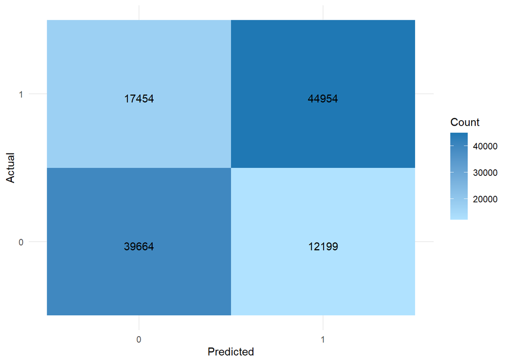

```r
conf_matrix <- table(Actual = testing$diabetes_012, Predicted = testing$predicted_LDA)

# Trực quan hóa confusion matrix
cm_table <- as.table(conf_matrix)
cm_melt <- as.data.frame(as.table(cm_table))

ggplot(data = cm_melt, aes(x = Actual, y = Predicted, fill = Freq)) +
  geom_tile() +
  geom_text(aes(label = sprintf("%d", Freq)), vjust = 1) +
  scale_fill_gradient(low = "lightskyblue1", high = "#1f78b4") +
  theme_minimal() +
  labs(x = "Predicted", y = "Actual", fill = "Count")
```

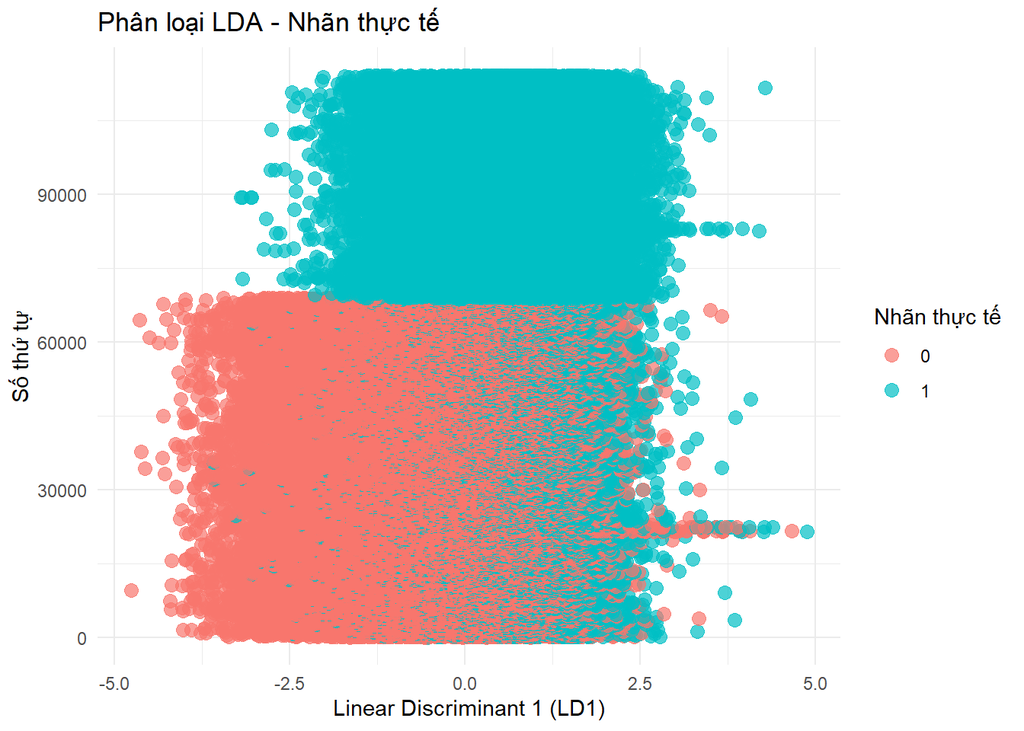

```r
# Bước 1: Tính toán giá trị discriminant
lda_pred <- predict(lda_diabetes_md5, testing)

# Bước 2: Trích xuất các giá trị discriminant (Linear Discriminants)
lda_values <- lda_pred$x  # Ma trận các giá trị discriminant

plot_data <- data.frame(
  LD1 = lda_values[, 1],  # Trục Linear Discriminant 1
  Actual = factor(testing$diabetes_012),   # Nhãn thực tế
  Predicted = factor(lda_pred$class)      # Nhãn dự đoán
)

# Thêm cột "Index" để làm trục y (số thứ tự các điểm)
plot_data <- plot_data %>%
  mutate(Index = 1:nrow(plot_data))  # Số thứ tự các điểm

# Vẽ phân loại dựa trên LD1 và nhãn thực tế
ggplot(plot_data, aes(x = LD1, y = Index, color = Actual)) +
  geom_point(alpha = 0.7, size = 3) +
  labs(
    title = "Phân loại LDA - Nhãn thực tế",
    x = "Linear Discriminant 1 (LD1)",
    y = "Số thứ tự",
    color = "Nhãn thực tế"
  ) +
  theme_minimal()
```

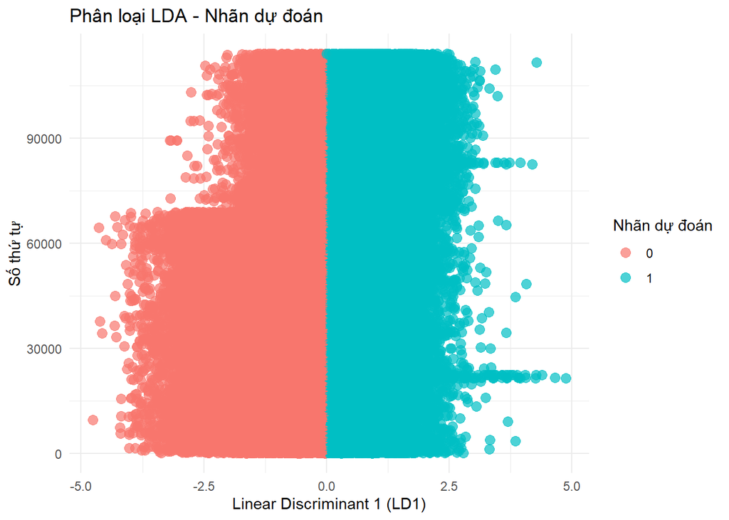

```r
# Vẽ phân loại dựa trên LD1 và nhãn dự đoán
ggplot(plot_data, aes(x = LD1, y = Index, color = Predicted)) +
  geom_point(alpha = 0.7, size = 3) +
  labs(
    title = "Phân loại LDA - Nhãn dự đoán",
    x = "Linear Discriminant 1 (LD1)",
    y = "Số thứ tự",
    color = "Nhãn dự đoán"
  ) +
  theme_minimal()
```

### 4.4.4 QDA

#### QDA trên tất cả các biến

#### Validation

```r
set.seed(123)
ind <- sample(2, nrow(diabetes1),
              replace = TRUE,
              prob = c(0.7, 0.3))
training <- diabetes1[ind==1,]
testing <- diabetes1[ind==2,]
```

#### Model

```r
qda_diabetes_md1 <- qda(diabetes_012 ~ ., data = training)
qda_diabetes_md1
```

```
## Call:
## qda(diabetes_012 ~ ., data = training)
##
## Prior probabilities of groups:
##          0          1          2
## 0.82696435 0.02046618 0.15256947
##
## Group means:
##    high_bp1 high_chol1 chol_check1      bmi   smoker1    stroke1
## 0 0.3946456  0.3948938   0.9523684 28.03123 0.4548094 0.03588918
## 1 0.6401216  0.6261398   0.9857143 30.85350 0.4917933 0.05744681
## 2 0.7524668  0.6685966   0.9927016 32.01174 0.5192449 0.09145397
##   heart_diseaseor_attack1 phys_activity1   fruits1  veggies1
## 0              0.07957153      0.7548237 0.6191730 0.8026057
## 1              0.14772036      0.6784195 0.5987842 0.7671733
## 2              0.22347713      0.6265188 0.5815053 0.7536084
##   hvy_alcohol_consump1 any_healthcare1 no_docbc_cost1 gen_hlth ment_hlth
## 0           0.06783664       0.9435146     0.08928289 2.461820  3.296516
## 1           0.04680851       0.9462006     0.12613982 2.975684  4.631307
## 2           0.02381147       0.9589415     0.10702928 3.296583  4.517492
##   phys_hlth diff_walk1      sex1        age2        age3       age4       age5
## 0  4.017038  0.1482206 0.4320994 0.036257776 0.050760887 0.06073554 0.06751318
## 1  6.271125  0.2808511 0.4306991 0.013677812 0.016109422 0.02887538 0.03434650
## 2  8.032578  0.3747452 0.4766778 0.004077306 0.009214711 0.01822556 0.03009052
##         age6       age7      age8      age9     age10      age11      age12
## 0 0.07986490 0.10348511 0.1182665 0.1229078 0.1157992 0.08607085 0.06069040
## 1 0.07234043 0.08875380 0.1121581 0.1495441 0.1504559 0.13373860 0.09817629
## 2 0.05031395 0.08705048 0.1203621 0.1629291 0.1860882 0.14621218 0.09337030
##        age13 education2 education3 education4 education5 education6    income2
## 0 0.06910040 0.01436771 0.03615999  0.2559032  0.2889414  0.4040034 0.04338145
## 1 0.09756839 0.03647416 0.07203647  0.2942249  0.2817629  0.3151976 0.07781155
## 2 0.08970073 0.03396396 0.06503303  0.3148903  0.2956047  0.2891217 0.08876295
##      income3    income4   income5   income6   income7   income8
## 0 0.06290198 0.08119636 0.1071109 0.1527039 0.1804539 0.3351362
## 1 0.09331307 0.10334347 0.1218845 0.1559271 0.1623100 0.2151976
## 2 0.10172878 0.11453152 0.1268450 0.1502895 0.1499633 0.2002365
```

• Có khoảng 82.7% quan sát được phân loại vào nhóm 0, tức là không có mắc bệnh tiểu đường;

• Có khoảng 2.05% quan sát được phân loại vào nhóm 1, tức tiền tiểu đường;

• Có khoảng 15.26% quan sát được phân loại vào nhóm 2, tức là có mắc bệnh tiểu đường;

```r
attributes(qda_diabetes_md1)
```

```
## $names
##  [1] "prior"   "counts"  "means"   "scaling" "ldet"    "lev"     "N"
##  [8] "call"    "terms"   "xlevels"
##
## $class
## [1] "qda"
```

```r
qda_diabetes_md1$count
```

```
##      0      1      2
## 132937   3290  24526
```

```r
pred_out_md_QDA <- predict(qda_diabetes_md1, newdata = testing)
posterior_probs <- pred_out_md_QDA$posterior
## Gán nhãn tập testing
testing$predicted_QDA <- colnames(posterior_probs)[max.col(posterior_probs)]
```

```r
conf_matrix <- table(Actual = testing$diabetes_012, Predicted = testing$predicted_QDA)
```

#### QDA trên một số biến có chọn lọc

#### Validation

```r
set.seed(123)
ind <- sample(2, nrow(diabetes1),
              replace = TRUE,
              prob = c(0.7, 0.3))
training <- diabetes1[ind==1,]
testing <- diabetes1[ind==2,]
```

#### Model

```r
qda_diabetes_md2 <- qda(formula = formula_model, data = training)
qda_diabetes_md2
```

```
## Call:
## qda(formula_model, data = training)
##
## Prior probabilities of groups:
##          0          1          2
## 0.82696435 0.02046618 0.15256947
##
## Group means:
##    high_bp1 high_chol1 chol_check1      bmi   smoker1    stroke1
## 0 0.3946456  0.3948938   0.9523684 28.03123 0.4548094 0.03588918
## 1 0.6401216  0.6261398   0.9857143 30.85350 0.4917933 0.05744681
## 2 0.7524668  0.6685966   0.9927016 32.01174 0.5192449 0.09145397
##   heart_diseaseor_attack1 phys_activity1 hvy_alcohol_consump1 gen_hlth
## 0              0.07957153      0.7548237           0.06783664 2.461820
## 1              0.14772036      0.6784195           0.04680851 2.975684
## 2              0.22347713      0.6265188           0.02381147 3.296583
##   ment_hlth phys_hlth diff_walk1        age2        age3       age4       age5
## 0  3.296516  4.017038  0.1482206 0.036257776 0.050760887 0.06073554 0.06751318
## 1  4.631307  6.271125  0.2808511 0.013677812 0.016109422 0.02887538 0.03434650
## 2  4.517492  8.032578  0.3747452 0.004077306 0.009214711 0.01822556 0.03009052
##         age6       age7      age8      age9     age10      age11      age12
## 0 0.07986490 0.10348511 0.1182665 0.1229078 0.1157992 0.08607085 0.06069040
## 1 0.07234043 0.08875380 0.1121581 0.1495441 0.1504559 0.13373860 0.09817629
## 2 0.05031395 0.08705048 0.1203621 0.1629291 0.1860882 0.14621218 0.09337030
##        age13    income2    income3    income4   income5   income6   income7
## 0 0.06910040 0.04338145 0.06290198 0.08119636 0.1071109 0.1527039 0.1804539
## 1 0.09756839 0.07781155 0.09331307 0.10334347 0.1218845 0.1559271 0.1623100
## 2 0.08970073 0.08876295 0.10172878 0.11453152 0.1268450 0.1502895 0.1499633
##     income8
## 0 0.3351362
## 1 0.2151976
## 2 0.2002365
```

• Có khoảng 82.7% quan sát được phân loại vào nhóm 0, tức là không có mắc bệnh tiểu đường;

• Có khoảng 2.05% quan sát được phân loại vào nhóm 1, tức tiền tiểu đường;

• Có khoảng 15.26% quan sát được phân loại vào nhóm 2, tức là có mắc bệnh tiểu đường;

```r
qda_diabetes_md2$count
```

```
##      0      1      2
## 132937   3290  24526
```

#### Evaluation

```r
pred_out_md_LDA <- predict(qda_diabetes_md2, newdata = testing)
posterior_probs <- pred_out_md_LDA$posterior
## Gán nhãn tập testing
testing$predicted_LDA <- colnames(posterior_probs)[max.col(posterior_probs)]
```

```r
conf_matrix <- table(Actual = testing$diabetes_012, Predicted = testing$predicted_LDA)
```

#### QDA trên một số biến có chọn lọc với biến mục tiêu thay đổi (2 nhóm)

#### Validation

```r
set.seed(123)
ind <- sample(2, nrow(diabetes2),
              replace = TRUE,
              prob = c(0.7, 0.3))
training <- diabetes2[ind==1,]
testing <- diabetes2[ind==2,]
```

#### Model

```r
qda_diabetes_md3 <- qda(formula = formula_model, data = training)
qda_diabetes_md3
```

```
## Call:
## qda(formula_model, data = training)
##
## Prior probabilities of groups:
##         0         1
## 0.8269643 0.1730357
##
## Group means:
##    high_bp1 high_chol1 chol_check1      bmi   smoker1    stroke1
## 0 0.3946456  0.3948938   0.9523684 28.03123 0.4548094 0.03588918
## 1 0.7391789  0.6635749   0.9918752 31.87475 0.5159980 0.08743169
##   heart_diseaseor_attack1 phys_activity1 hvy_alcohol_consump1 gen_hlth
## 0              0.07957153      0.7548237           0.06783664 2.461820
## 1              0.21451682      0.6326575           0.02653149 3.258628
##   ment_hlth phys_hlth diff_walk1        age2       age3       age4       age5
## 0  3.296516  4.017038  0.1482206 0.036257776 0.05076089 0.06073554 0.06751318
## 1  4.530953  7.824238  0.3636396 0.005212827 0.01003020 0.01948519 0.03059390
##         age6       age7      age8      age9     age10      age11      age12
## 0 0.07986490 0.10348511 0.1182665 0.1229078 0.1157992 0.08607085 0.06069040
## 1 0.05291918 0.08725194 0.1193917 0.1613460 0.1818737 0.14473684 0.09393874
##        age13    income2    income3    income4   income5   income6   income7
## 0 0.06910040 0.04338145 0.06290198 0.08119636 0.1071109 0.1527039 0.1804539
## 1 0.09063129 0.08746764 0.10073339 0.11320823 0.1262583 0.1509563 0.1514236
##     income8
## 0 0.3351362
## 1 0.2020060
```

• Có khoảng 82.7% quan sát được phân loại vào nhóm 0, tức là không có mắc bệnh tiểu đường;

• Có khoảng 17.31% quan sát được phân loại vào nhóm 1, tức mắc bệnh tiểu đường;

```r
qda_diabetes_md3$count
```

```
##      0      1
## 132937  27816
```

#### Evaluation

```r
pred_out_md_LDA <- predict(qda_diabetes_md3, newdata = testing)
posterior_probs <- pred_out_md_LDA$posterior
## Gán nhãn tập testing
testing$predicted_LDA <- colnames(posterior_probs)[max.col(posterior_probs)]
```

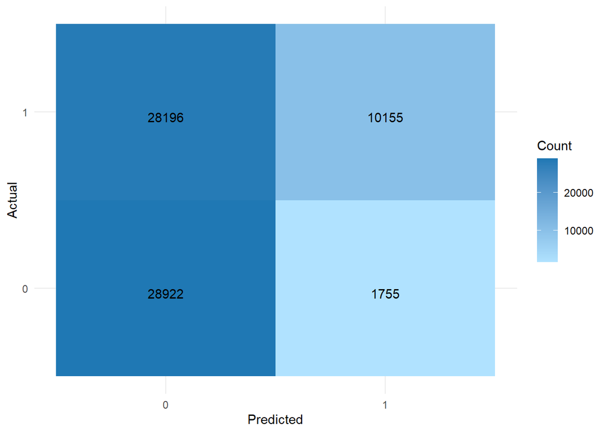

```r
conf_matrix <- table(Actual = testing$diabetes_012, Predicted = testing$predicted_LDA)

# Trực quan hóa confusion matrix
cm_table <- as.table(conf_matrix)
cm_melt <- as.data.frame(as.table(cm_table))

ggplot(data = cm_melt, aes(x = Actual, y = Predicted, fill = Freq)) +
  geom_tile() +
  geom_text(aes(label = sprintf("%d", Freq)), vjust = 1) +
  scale_fill_gradient(low = "lightskyblue1", high = "#1f78b4") +
  theme_minimal() +
  labs(x = "Predicted", y = "Actual", fill = "Count")
```

### 4.4.6 QDA: Imbalanced Data

#### QDA trên balance data 3 nhóm

#### Validation

```r
set.seed(123)
ind <- sample(2, nrow(smotenc_diabetes1),
              replace = TRUE,
              prob = c(0.7, 0.3))
training <- smotenc_diabetes1[ind==1,]
testing <- smotenc_diabetes1[ind==2,]
```

#### Model

```r
qda_diabetes_md4 <- qda(formula = formula_model, data = training)
qda_diabetes_md4
```

```
## Call:
## qda(formula_model, data = training)
##
## Prior probabilities of groups:
##         0         1         2
## 0.3329701 0.3330503 0.3339796
##
## Group means:
##    high_bp1 high_chol1 chol_check1      bmi   smoker1    stroke1
## 0 0.3946456  0.3948938   0.9523684 28.03123 0.4548094 0.03588918
## 1 0.6434733  0.6360054   0.9994284 30.51135 0.4930999 0.01611654
## 2 0.7685541  0.6784836   0.9981251 31.84597 0.5200015 0.06926654
##   heart_diseaseor_attack1 phys_activity1 hvy_alcohol_consump1 gen_hlth
## 0              0.07957153      0.7548237           0.06783664 2.461820
## 1              0.10788229      0.6962751           0.01024299 2.935414
## 2              0.20826459      0.6361182           0.01050697 3.284150
##   ment_hlth phys_hlth diff_walk1        age2        age3       age4       age5
## 0  3.296516  4.017038  0.1482206 0.036257776 0.050760887 0.06073554 0.06751318
## 1  3.854788  5.652066  0.2543375 0.004459686 0.005948755 0.02062887 0.01778610
## 2  4.022816  7.617212  0.3666867 0.001604920 0.004559772 0.01122694 0.02162892
##         age6       age7      age8      age9     age10      age11      age12
## 0 0.07986490 0.10348511 0.1182665 0.1229078 0.1157992 0.08607085 0.06069040
## 1 0.05491506 0.08401206 0.1256533 0.1750859 0.1781693 0.13806226 0.09755657
## 2 0.04065547 0.08167842 0.1225139 0.1716814 0.1998875 0.15650967 0.09520774
##        age13    income2    income3    income4   income5   income6   income7
## 0 0.06910040 0.04338145 0.06290198 0.08119636 0.1071109 0.1527039 0.1804539
## 1 0.09609007 0.05680271 0.08278621 0.08853943 0.1166212 0.1715663 0.1702352
## 2 0.09185541 0.08051597 0.09586021 0.11150442 0.1296610 0.1547023 0.1552797
##     income8
## 0 0.3351362
## 1 0.2547586
## 2 0.2136643
```

• Có khoảng 33.3% quan sát được phân loại vào nhóm 0, tức là không có mắc bệnh tiểu đường;

• Có khoảng 33.3% quan sát được phân loại vào nhóm 1, tức tiền tiểu đường;

• Có khoảng 33.4% quan sát được phân loại vào nhóm 2, tức là có mắc bệnh tiểu đường;

```r
qda_diabetes_md4$count
```

```
##      0      1      2
## 132937 132969 133340
```

#### Evaluation

```r
pred_out_md_LDA <- predict(qda_diabetes_md4, newdata = testing)
posterior_probs <- pred_out_md_LDA$posterior
## Gán nhãn tập testing
testing$predicted_LDA <- colnames(posterior_probs)[max.col(posterior_probs)]
```

```r
conf_matrix <- table(Actual = testing$diabetes_012, Predicted = testing$predicted_LDA)
```

#### QDA trên balanced data 2 nhóm

#### Validation

```r
set.seed(123)
ind <- sample(2, nrow(smotenc_diabetes2),
              replace = TRUE,
              prob = c(0.7, 0.3))
training <- smotenc_diabetes2[ind==1,]
testing <- smotenc_diabetes2[ind==2,]
```

#### Model

```r
qda_diabetes_md5 <- qda(formula = formula_model, data = training)
qda_diabetes_md5
```

```
## Call:
## qda(formula_model, data = training)
##
## Prior probabilities of groups:
##         0         1
## 0.5000658 0.4999342
##
## Group means:
##    high_bp1 high_chol1 chol_check1      bmi   smoker1    stroke1
## 0 0.3946456  0.3948938   0.9523684 28.03123 0.4548094 0.03588918
## 1 0.7538788  0.6749108   0.9975621 31.70695 0.5156431 0.06632707
##   heart_diseaseor_attack1 phys_activity1 hvy_alcohol_consump1 gen_hlth
## 0              0.07957153      0.7548237           0.06783664 2.461820
## 1              0.19929723      0.6409083           0.01200885 3.246749
##   ment_hlth phys_hlth diff_walk1        age2        age3       age4       age5
## 0  3.296516  4.017038  0.1482206 0.036257776 0.050760887 0.06073554 0.06751318
## 1  4.016944  7.407394  0.3538096 0.002422838 0.005507818 0.01306226 0.02208394
##         age6       age7      age8      age9     age10      age11      age12
## 0 0.07986490 0.10348511 0.1182665 0.1229078 0.1157992 0.08607085 0.06069040
## 1 0.04334021 0.08282042 0.1229026 0.1715174 0.1964605 0.15290966 0.09465621
##        age13    income2    income3    income4   income5   income6   income7
## 0 0.06910040 0.04338145 0.06290198 0.08119636 0.1071109 0.1527039 0.1804539
## 1 0.09124769 0.07953229 0.09446058 0.11044228 0.1273645 0.1558366 0.1549563
##     income8
## 0 0.3351362
## 1 0.2174911
```

• Có khoảng 50% quan sát được phân loại vào nhóm 0, tức là không có mắc bệnh tiểu đường;

• Có khoảng 50% quan sát được phân loại vào nhóm 1, tức mắc bệnh tiểu đường;

```r
lda_diabetes_md5$count
```

```
##      0      1
## 132937 132902
```

#### Evaluation

```r
pred_out_md_LDA <- predict(qda_diabetes_md5, newdata = testing)
posterior_probs <- pred_out_md_LDA$posterior
## Gán nhãn tập testing
testing$predicted_LDA <- colnames(posterior_probs)[max.col(posterior_probs)]
```

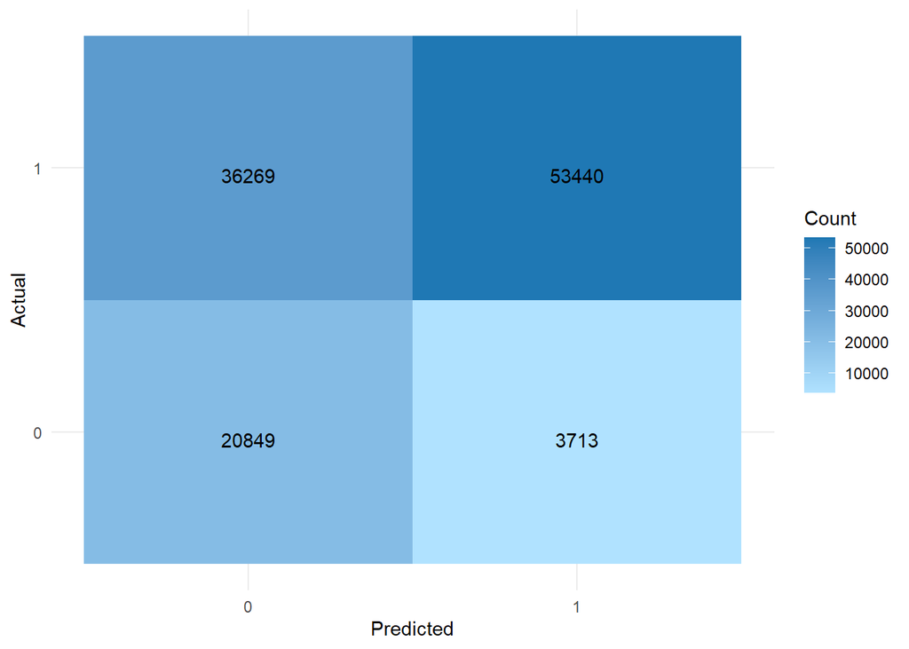

```r
conf_matrix <- table(Actual = testing$diabetes_012, Predicted = testing$predicted_LDA)

# Trực quan hóa confusion matrix
cm_table <- as.table(conf_matrix)
cm_melt <- as.data.frame(as.table(cm_table))

ggplot(data = cm_melt, aes(x = Actual, y = Predicted, fill = Freq)) +
  geom_tile() +
  geom_text(aes(label = sprintf("%d", Freq)), vjust = 1) +
  scale_fill_gradient(low = "lightskyblue1", high = "#1f78b4") +
  theme_minimal() +
  labs(x = "Predicted", y = "Actual", fill = "Count")
```